# PM2.5 Air Quality Analysis: Changes from 1999 to 2012

Yuan Zhuang

2025-09-22

Hello everyone! I’m Yuan Zhuang, a new PhD student from the School of Risk & Actuarial Studies.

# Introduction

The EPA Air Quality System publishes air quality data on a continuous basis. The data is a delimited file where fields are delimited with the ‘|’ character and missing values are coded as blank fields. The fields are called: RD, Action.Code, State.Code, County.Code, Site.ID, Parameter, POC, Sample.Duration, Unit Method, Date, Start.Time, Sample.Value, etc. The air quality index on fine particulate matter air pollution (PM2.5) is in the column titled Sample.Value. More details on the descriptions of the data can be found at: https://aqs.epa.gov/aqsweb/airdata/FileFormats.html. The State.Code details in the dataset can be found here: https://www.mercercountypa.gov/dps/state_fips_code_listing.htm

The two data files are named: 1. Airpollution_1999.txt, and 2. Airpollution_2012.txt

# Research Question

**Main Question:** Has PM2.5 levels decreased from 1999 to 2012?

To make this analysis more specific and feasible, I refined the question to: - For the same county in 1999 and 2012 during the same month, has the monthly average PM2.5 decreased? - Which parts of the United States show improvements? Which counties have not improved?

# Data Import and Processing

## Loading Required Libraries

```r
# Load required libraries
library(dplyr)
library(readr)
library(ggplot2)
library(maps)
library(usmap)
library(viridis)
```

## Data Import Function

```r
# Function to read and process PM2.5 data
process_pm25_data <- function(file_path, year) {
  cat("Processing", year, "data from:", file_path, "\n")
  # Read the data file
  # Skip the first two header lines and read with pipe delimiter
  data <- read_delim(file_path,
                     delim = "|",
                     skip = 2,
                     col_names = FALSE,
                     show_col_types = FALSE)

  # Set column names based on the header information
  col_names <- c("RD_RC", "Action_Code", "State_Code", "County_Code", "Site_ID",
                 "Parameter", "POC", "Sample_Duration", "Unit", "Method",
                 "Date", "Start_Time", "Sample_Value", "Null_Data_Code",
                 "Sampling_Frequency", "Monitor_Protocol_ID", "Qualifier_1",
                 "Qualifier_2", "Qualifier_3", "Qualifier_4", "Qualifier_5",
                 "Qualifier_6", "Qualifier_7", "Qualifier_8", "Qualifier_9",
                 "Qualifier_10", "Alternate_Method_Detectable_Limit", "Uncertainty")

  # Assign column names
  names(data) <- col_names[1:ncol(data)]

  # Convert Sample_Value to numeric, keeping NA values
  data$Sample_Value <- as.numeric(data$Sample_Value)
  # Omit the last row, which is a comment in the data
  data <- data[1:nrow(data)-1,]

  # Group by State Code, County Code, Date, and Start Time
  # Calculate mean Sample Value for each group
  grouped_data <- data %>%
    group_by(State_Code, County_Code, Date, Start_Time) %>%
    summarise(
      sample_value = if(all(is.na(Sample_Value))) {
        NA  # If all values are NA, return NA
      } else {
        mean(Sample_Value, na.rm = TRUE)  # If any non-NA exists, omit NA values
      },
      .groups = 'drop'
    )

  return(grouped_data)
}
```

## Data Processing Steps

```r
# Process 1999 data
pm25_1999 <- process_pm25_data("Airpollution_1999.txt", 1999)
```

```
## Processing 1999 data from: Airpollution_1999.txt
```

```r
# Process 2012 data
pm25_2012 <- process_pm25_data("Airpollution_2012.txt", 2012)
```

```
## Processing 2012 data from: Airpollution_2012.txt
```

```r
# Filter 2012 data to only include start_time = "00:00:00" for fair comparison with 1999
# Since 1999 data only has start_time = "00:00:00"
cat("\n=== Filtering 2012 data ===\n")
```

```
##
## === Filtering 2012 data ===
```

```r
cat("2012 data before filtering:", nrow(pm25_2012), "\n")
```

```
## 2012 data before filtering: 950117
```

```r
# Since Start_Time is in hms format, we can convert it to character and filter
pm25_2012 <- pm25_2012 %>%
  mutate(Start_Time_char = as.character(Start_Time)) %>%
  filter(Start_Time_char == "00:00:00") %>%
  select(-Start_Time_char)

cat("2012 data after filtering (00:00:00 only):", nrow(pm25_2012), "\n")
```

```
## 2012 data after filtering (00:00:00 only): 75283
```

```r
# Display summary statistics
cat("\n=== Summary Statistics ===\n")
```

```
##
## === Summary Statistics ===
```

```r
cat("1999 data recordings:", nrow(pm25_1999), "\n")
```

```
## 1999 data recordings: 75061
```

```r
cat("2012 data recordings:", nrow(pm25_2012), "\n")
```

```
## 2012 data recordings: 75283
```

## Monthly Aggregation

```r
# Function to aggregate data by month
aggregate_by_month <- function(data, year) {
  cat("\n=== Aggregating", year, "data by month ===\n")

  # Convert Date to proper date format and extract month
  data$Date_formatted <- as.Date(as.character(data$Date), format = "%Y%m%d")
  data$Time <- format(data$Date_formatted, "%Y-%m")
  data$Month <- as.numeric(substr(data$Time, 6, 7))  # Extract month number

  # Group by State Code, County Code, and Month, then calculate mean
  monthly_data <- data %>%
    group_by(State_Code, County_Code, Month) %>%
    summarise(
      sample_value = if(all(is.na(sample_value))) {
        NA  # If all values are NA, return NA
      } else {
        mean(sample_value, na.rm = TRUE)  # If any non-NA exists, omit NA values
      },
      .groups = 'drop'
    )
  cat("Monthly aggregated data for", year, ":", nrow(monthly_data), "records\n")
  return(monthly_data)
}

# Aggregate both datasets by month
pm25_1999_monthly <- aggregate_by_month(pm25_1999, 1999)
```

```
##
## === Aggregating 1999 data by month ===
## Monthly aggregated data for 1999 : 6250 records
```

```r
pm25_2012_monthly <- aggregate_by_month(pm25_2012, 2012)
```

```
##
## === Aggregating 2012 data by month ===
## Monthly aggregated data for 2012 : 4210 records
```

```r
# Display monthly aggregation statistics
cat("\n=== Monthly Aggregation Summary ===\n")
```

```
##
## === Monthly Aggregation Summary ===
```

```r
cat("1999 monthly records:", nrow(pm25_1999_monthly), "\n")
```

```
## 1999 monthly records: 6250
```

```r
cat("2012 monthly records:", nrow(pm25_2012_monthly), "\n")
```

```
## 2012 monthly records: 4210
```

# Data Quality Issues and Solutions

## Issues Identified

1. **Different recording frequencies**: 2012 data has much higher recording frequency than 1999. I addressed this by averaging the data to align granularity to county and month level, and by selecting only 00:00 records.
2. **Systematic missing data in 2012**: The second half of 2012 data is systematically missing. Therefore, I focus the analysis on the first half of the year.
3. **Systematic missing data of some counties in the US**: The data provided does not record all the information of US counties. For those not recorded, I skipped them.
4. **Missing values**: This didn’t significantly impact my analysis. When aggregating data and creating plots, I use `na.rm = TRUE` to handle most issues. If it affects plotting, I display those areas in gray.

## Month Distribution Analysis

This is to support the statement above: “The second half of 2012 data is systematically missing.”

```r
# Month Distribution Analysis using monthly data
cat("\n=== Month Distribution Analysis ===\n")
```

```
##
## === Month Distribution Analysis ===
```

```r
# Count records by month for each year
month_counts_1999 <- pm25_1999_monthly %>%
  count(Month) %>%
  arrange(Month)

month_counts_2012 <- pm25_2012_monthly %>%
  count(Month) %>%
  arrange(Month)

# Check if 2012 data is concentrated in first 6 months
months_1999 <- sort(unique(pm25_1999_monthly$Month))
months_2012 <- sort(unique(pm25_2012_monthly$Month))

cat("\n=== Analysis Results ===\n")
```

```
##
## === Analysis Results ===
```

```r
cat("1999 has data for", length(months_1999), "months:", paste(months_1999, collapse = ", "), "\n")
```

```
## 1999 has data for 12 months: 1, 2, 3, 4, 5, 6, 7, 8, 9, 10, 11, 12
```

```r
cat("2012 has data for", length(months_2012), "months:", paste(months_2012, collapse = ", "), "\n")
```

```
## 2012 has data for 10 months: 1, 2, 3, 4, 5, 6, 7, 8, 9, 10
```

The following figure shows there is a lack of records in the second half of 2012.

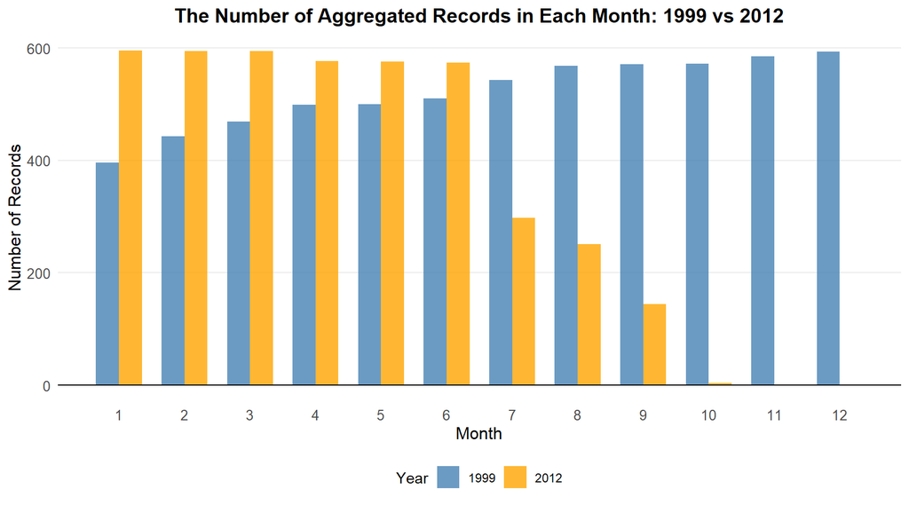

```r
# Create complete month data for visualization
all_months <- data.frame(Month = 1:12)

# Merge with actual data to get complete picture
month_data_1999 <- all_months %>%
  left_join(month_counts_1999, by = "Month") %>%
  mutate(n = ifelse(is.na(n), 0, n),
         Year = "1999")

month_data_2012 <- all_months %>%
  left_join(month_counts_2012, by = "Month") %>%
  mutate(n = ifelse(is.na(n), 0, n),
         Year = "2012")

# Combine data for plotting
combined_data <- bind_rows(month_data_1999, month_data_2012)

# Create count distribution plot
p <- ggplot(combined_data, aes(x = Month, y = n, fill = Year)) +
  geom_bar(stat = "identity", position = "dodge", alpha = 0.8, width = 0.7) +
  scale_fill_manual(values = c("1999" = "steelblue", "2012" = "orange")) +
  scale_x_continuous(breaks = 1:12, labels = 1:12) +
  labs(title = "The Number of Aggregated Records in Each Month: 1999 vs 2012",
       x = "Month",
       y = "Number of Records",
       fill = "Year") +
  theme_minimal() +
  theme(plot.title = element_text(hjust = 0.5, size = 14, face = "bold"),
        axis.text = element_text(size = 10),
        axis.title = element_text(size = 12),
        legend.position = "bottom",
        panel.grid.major.x = element_blank(),
        panel.grid.minor = element_blank()) +
  geom_hline(yintercept = 0, color = "black", size = 0.5)

print(p)
```

```r
# Save the plot
ggsave("month_distribution_comparison.png", plot = p, width = 12, height = 8, dpi = 300)
```

# Main Analysis: PM2.5 Changes

## Data Comparison Setup

In this chunk, we merge the 1999 and 2012 dataset.

```r
# Main Analysis: Compare PM2.5 levels between 1999 and 2012
cat("\n=== Main Analysis: PM2.5 Change from 1999 to 2012 ===\n")
```

```
##
## === Main Analysis: PM2.5 Change from 1999 to 2012 ===
```

```r
# Merge the two datasets by State_Code, County_Code, and Month
# Only join where both datasets have the same location and month
comparison_data <- pm25_1999_monthly %>%
  select(State_Code, County_Code, Month, sample_value) %>%
  rename(sample_value_1999 = sample_value) %>%
  inner_join(
    pm25_2012_monthly %>%
      select(State_Code, County_Code, Month, sample_value) %>%
      rename(sample_value_2012 = sample_value),
    by = c("State_Code", "County_Code", "Month")
  )

# Calculate the difference (2012 - 1999)
comparison_data$pm25_change <- comparison_data$sample_value_2012 - comparison_data$sample_value_1999

# All rows in comparison_data now have both 1999 and 2012 data
comparison_data_complete <- comparison_data

cat("Total comparison pairs (same location and month):", nrow(comparison_data_complete), "\n")
```

```
## Total comparison pairs (same location and month): 2830
```

## Summary Statistics

It can be seen that about 85% counties has witnessed a drop in PM2.5. So PM2.5 levels decreased from 1999 to 2012 for most US couties.

```r
# Summary statistics of PM2.5 changes
cat("\n=== PM2.5 Change Summary ===\n")
```

```
##
## === PM2.5 Change Summary ===
```

```r
cat("Mean PM2.5 change (2012 - 1999):", round(mean(comparison_data_complete$pm25_change, na.rm = TRUE), 3))
```

```
## Mean PM2.5 change (2012 - 1999): -4.552
```

```r
# Count improvements vs deteriorations
improvements <- sum(comparison_data_complete$pm25_change < 0, na.rm = TRUE)
deteriorations <- sum(comparison_data_complete$pm25_change > 0, na.rm = TRUE)
no_change <- sum(comparison_data_complete$pm25_change == 0, na.rm = TRUE)

cat("\n=== Change Distribution ===\n")
```

```
##
## === Change Distribution ===
```

```r
cat("Locations with PM2.5 reduction (improvement):", improvements, "(", round(improvements/nrow(comparison_data_complete)*100, 1), "%)\n")
```

```
## Locations with PM2.5 reduction (improvement): 2416 ( 85.4 %)
```

```r
cat("Locations with PM2.5 increase (deterioration):", deteriorations, "(", round(deteriorations/nrow(comparison_data_complete)*100, 1), "%)\n")
```

```
## Locations with PM2.5 increase (deterioration): 364 ( 12.9 %)
```

```r
cat("Locations with no change:", no_change, "(", round(no_change/nrow(comparison_data_complete)*100, 1), "%)\n")
```

```
## Locations with no change: 0 ( 0 %)
```

## Monthly Analysis

For March, April and May, there is a smaller improvement.

```r
# Analysis by month
monthly_summary <- comparison_data_complete %>%
  group_by(Month) %>%
  summarise(
    n_locations = n(),
    mean_change = mean(pm25_change, na.rm = TRUE),
    median_change = median(pm25_change, na.rm = TRUE),
    improvements = sum(pm25_change < 0, na.rm = TRUE),
    deteriorations = sum(pm25_change > 0, na.rm = TRUE),
    .groups = 'drop'
  ) %>%
  arrange(Month)

print(monthly_summary)
```

```
## # A tibble: 10 × 6
##    Month n_locations mean_change median_change improvements deteriorations
##    <dbl>       <int>       <dbl>         <dbl>        <int>          <int>
##  1     1         331       -6.07         -6.04          284             33
##  2     2         371       -4.26         -4.70          315             49
##  3     3         387       -3.27         -3.28          313             62
##  4     4         403       -3.26         -3.30          354             46
##  5     5         405       -3.37         -3.40          330             71
##  6     6         408       -5.68         -5.45          359             45
##  7     7         220       -5.41         -5.07          187             30
##  8     8         189       -6.56         -5.50          172             15
##  9     9         113       -5.04         -5.42           99             13
## 10    10           3      -12.0         -14               3              0
```

## Visualizations

### Distribution of PM2.5 Changes

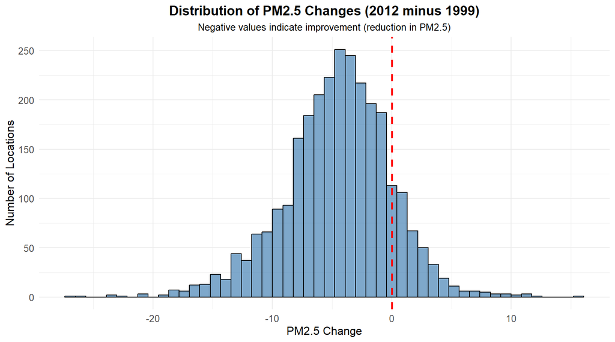

```r
# Create visualization of PM2.5 changes
p2 <- ggplot(comparison_data_complete, aes(x = pm25_change)) +
  geom_histogram(bins = 50, fill = "steelblue", alpha = 0.7, color = "black") +
  geom_vline(xintercept = 0, color = "red", linetype = "dashed", size = 1) +
  labs(title = "Distribution of PM2.5 Changes (2012 minus 1999)",
       x = "PM2.5 Change",
       y = "Number of Locations",
       subtitle = "Negative values indicate improvement (reduction in PM2.5)") +
  theme_minimal() +
  theme(plot.title = element_text(hjust = 0.5, size = 14, face = "bold"),
        plot.subtitle = element_text(hjust = 0.5, size = 10),
        axis.text = element_text(size = 10),
        axis.title = element_text(size = 12))

print(p2)
```

```r
# Save the plot
ggsave("pm25_change_distribution.png", plot = p2, width = 12, height = 8, dpi = 300)
```

### Monthly Change Trends

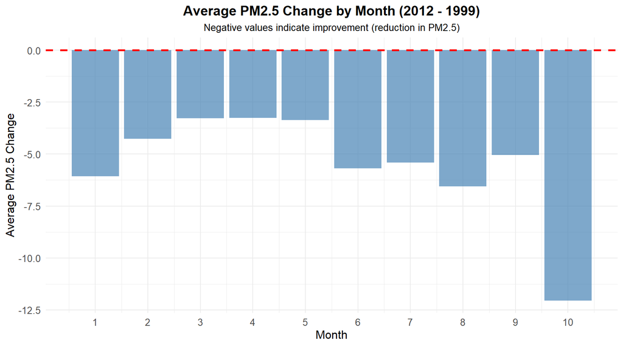

```r
# Monthly change visualization
p3 <- ggplot(monthly_summary, aes(x = Month, y = mean_change)) +
  geom_bar(stat = "identity", fill = "steelblue", alpha = 0.7) +
  geom_hline(yintercept = 0, color = "red", linetype = "dashed", size = 1) +
  scale_x_continuous(breaks = 1:12, labels = 1:12) +
  labs(title = "Average PM2.5 Change by Month (2012 - 1999)",
       x = "Month",
       y = "Average PM2.5 Change",
       subtitle = "Negative values indicate improvement (reduction in PM2.5)") +
  theme_minimal() +
  theme(plot.title = element_text(hjust = 0.5, size = 14, face = "bold"),
        plot.subtitle = element_text(hjust = 0.5, size = 10),
        axis.text = element_text(size = 10),
        axis.title = element_text(size = 12))

print(p3)
```

```r
# Save the plot
ggsave("monthly_pm25_change_trends.png", plot = p3, width = 12, height = 8, dpi = 300)
```

# Geographic Analysis: County-Level Maps

## Map Creation Function

We map the FIPS codes to each counties, using package `usmap`. Here, we only plot the figures from January to June.

```r
# Function to create county-level FIPS codes
create_fips <- function(state_code, county_code) {
  # Pad state code to 2 digits and county code to 3 digits
  state_padded <- sprintf("%02d", as.numeric(state_code))
  county_padded <- sprintf("%03d", as.numeric(county_code))
  return(paste0(state_padded, county_padded))
}

# Add FIPS codes to comparison data
comparison_data_maps <- comparison_data_complete %>%
  mutate(fips = create_fips(State_Code, County_Code))

# Filter data for January through June
monthly_data_list <- list()
month_names <- c("January", "February", "March", "April", "May", "June")

for(i in 1:6) {
  monthly_data_list[[i]] <- comparison_data_maps %>%
    filter(Month == i) %>%
    select(fips, pm25_change)
  cat(month_names[i], "data points:", nrow(monthly_data_list[[i]]), "\n")
}
```

```
## January data points: 331
## February data points: 371
## March data points: 387
## April data points: 403
## May data points: 405
## June data points: 408
```

## Map Visualizations

For March, April, and May, the improvement in PM2.5 levels is relatively modest. A decline in PM2.5 is observed across counties in the southeastern United States between February and May. In Southern California, PM2.5 concentrations show a consistent decrease from January through June.

```
## Creating January map...
```

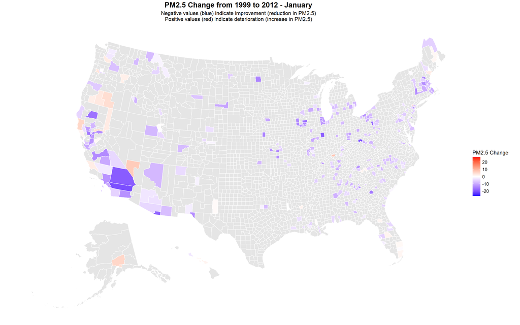

```
## January map saved as pm25_change_january_map.png
## Creating February map...
```

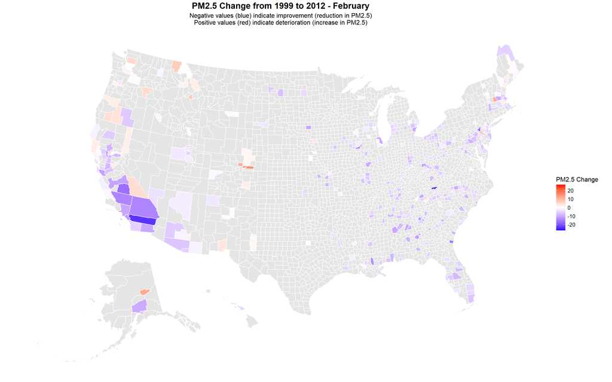

```
## February map saved as pm25_change_february_map.png
## Creating March map...
```

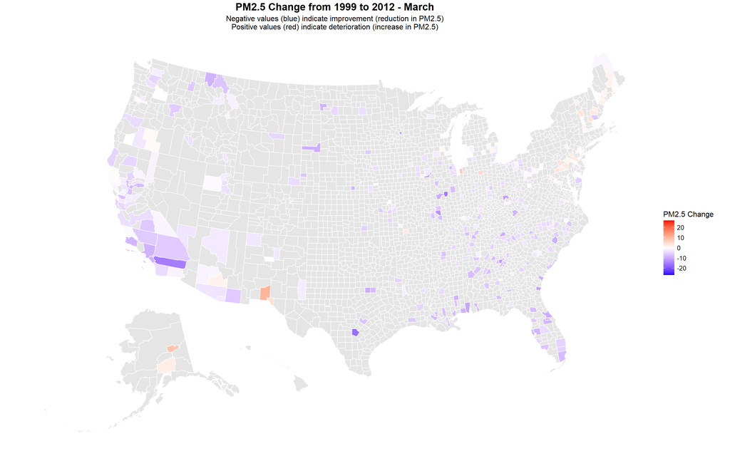

```
## March map saved as pm25_change_march_map.png
## Creating April map...
```

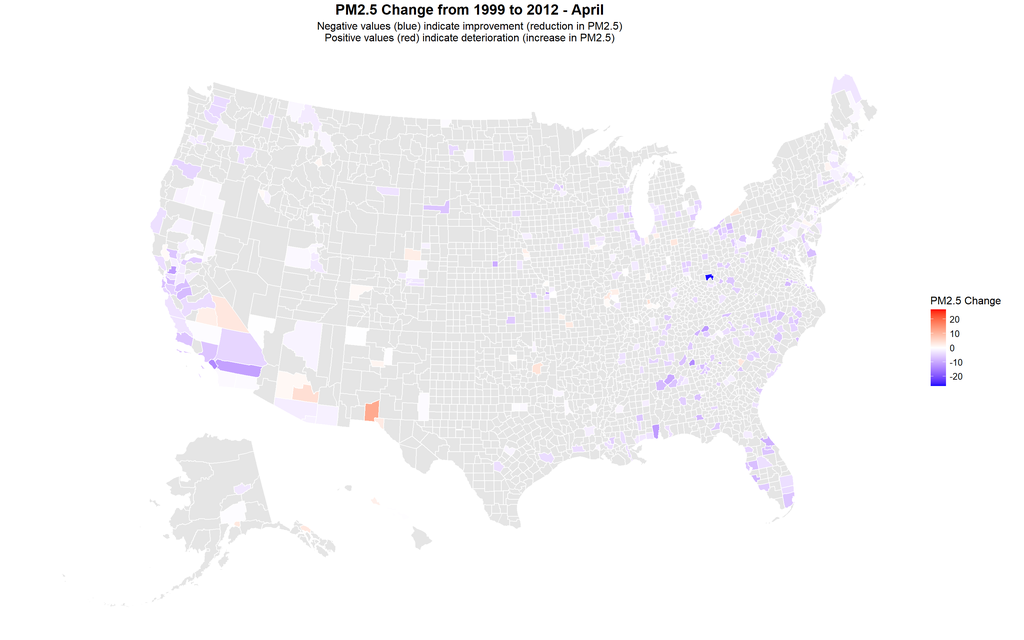

```
## April map saved as pm25_change_april_map.png
## Creating May map...
```

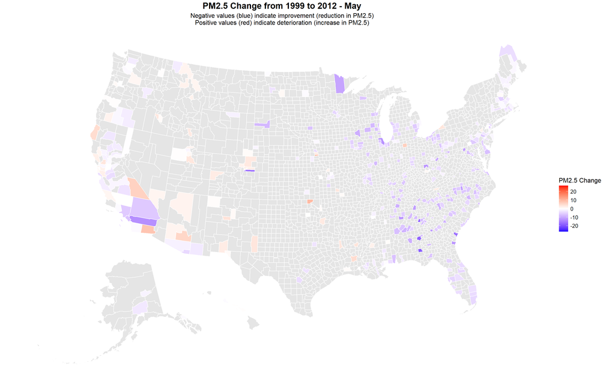

```
## May map saved as pm25_change_may_map.png
## Creating June map...
```

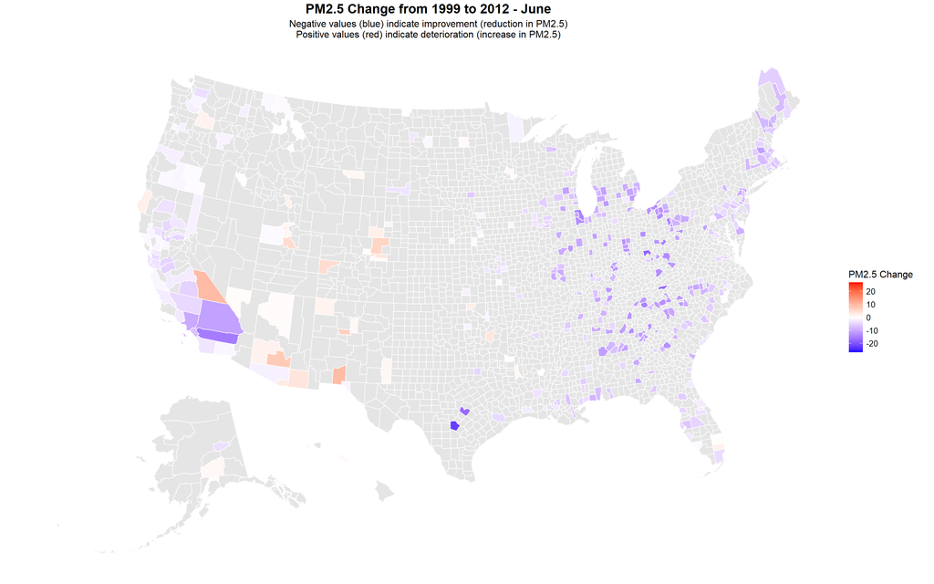

```
## June map saved as pm25_change_june_map.png
```

```r
# Create maps for January through June
for(i in 1:6) {
  if(nrow(monthly_data_list[[i]]) > 0) {
    cat("Creating", month_names[i], "map...\n")

    p_month <- plot_usmap(
      regions = "counties",
      data = monthly_data_list[[i]],
      values = "pm25_change",
      color = "white",
      size = 0.1
    ) +
      scale_fill_gradient2(
        name = "PM2.5 Change",
        low = "blue",
        mid = "white",
        high = "red",
        midpoint = 0,
        na.value = "grey90",
        limits = c(-max(abs(comparison_data_complete$pm25_change), na.rm = TRUE),
                   max(abs(comparison_data_complete$pm25_change), na.rm = TRUE))
      ) +
      labs(
        title = paste("PM2.5 Change from 1999 to 2012 -", month_names[i]),
        subtitle = "Negative values (blue) indicate improvement (reduction in PM2.5)\nPositive values (red) indicate deterioration (increase in PM2.5)"
      ) +
      theme(
        plot.title = element_text(hjust = 0.5, size = 16, face = "bold"),
        plot.subtitle = element_text(hjust = 0.5, size = 12),
        legend.position = "right",
        legend.title = element_text(size = 12),
        legend.text = element_text(size = 10)
      )

    print(p_month)

    # Save the map
    filename <- paste0("pm25_change_", tolower(month_names[i]), "_map.png")
    ggsave(filename, plot = p_month, width = 16, height = 10, dpi = 300)
    cat(month_names[i], "map saved as", filename, "\n")
  }
}
```

# Conclusions

Based on the analysis of PM2.5 data from 1999 to 2012, we can draw several key conclusions:

1. **Overall Trend**: The analysis shows PM2.5 levels have generally decreased across different counties and months.
2. **Geographic Patterns**: PM2.5 levels decline across counties in the southeastern United States from February to May, while Southern California experiences a steady reduction from January through June.
3. **Seasonal Variations**: In March through May, the reduction in PM2.5 levels remains rather modest.
4. **Data Limitations**: The analysis is limited to the first half of 2012 due to systematic missing data in the latter part of the year.

The visualizations and statistical summaries provide a comprehensive view of air quality changes, helping to answer the research questions about PM2.5 trends and geographic distribution of improvements.